# Dengue no Distrito Federal

Vigilâcia Laboratorial e Epidemiológica

Autor

GECAMP/CIEVS-DF

Data de Publicação

20 de janeiro de 2024

[figure not shown]

# Introdução

A dengue é uma doença viral transmitida pelo mosquito Aedes aegypti, com sintomas como febre alta, dor de cabeça, dores musculares e erupções cutâneas. No Distrito Federal (DF), a vigilância epidemiológica dessa doença inclui o monitoramento das notificações de casos feitas Sistema de Informação de Agravos de Notificação (SINAN). Além disso, a vigilância laboratorial desempenha um papel crucial na confirmação diagnóstica da doença, identificando o vírus da dengue em amostras de pacientes suspeitos. A vigilância contínua é essencial para a saúde pública no DF, minimizando os impactos da dengue na população.

O sistema TrakCare, utilizado no Distrito Federal, é um sistema de informação em saúde que registra e gerencia dados de pacientes, incluindo testes diagnósticos e resultados de exames. Esse sistema é essencial para o monitoramento de doenças como a dengue, pois facilita a coleta de dados mais opotunos do que os reportados no SINAN. Segundo o *Guia de Vigilância em Saúde* (2023) o disgnóstico pode se dar poe:

**O diagnóstico por PCR (Reação em Cadeia da Polimerase):** É o método mais preciso para a detecção do vírus da dengue, particularmente na fase aguda da doença (nos primeiros 5 dias de sintomas). O PCR é capaz de identificar o RNA viral, permitindo não apenas confirmar a presença do vírus, mas também determinar o sorotipo específico.

**Diagnóstico por Sorologia:** Este método é utilizado após o quinto dia do início dos sintomas. Ele detecta anticorpos IgM e IgG no sangue do paciente. Enquanto IgM é indicativo de uma infecção recente, IgG pode indicar uma infecção passada ou uma reinfecção. A sorologia é útil para diagnóstico tardio e para a realização de estudos epidemiológicos.

**Teste Rápido:** É um método de triagem, usado para uma rápida detecção de anticorpos contra o vírus da dengue em ambientes clínicos. Este teste é prático e fornece resultados rápidos, mas tem uma sensibilidade e especificidade menores em comparação com o PCR e a sorologia. De acordo com as diretrizes, ele não deve ser usado para confirmação laboratorial da doença .

# Análise dos dados

Para analisar a situação epidemiológica da dengue no Distrito Federal, foram utilizados dados obtidos do sistema TrakCare e do SINAN (Sistema de Informação de Agravos de Notificação) a partir de janeiro de 2023. Os dados selecionados incluíram apenas residentes do Distrito Federal, concentrando-se em exames com resultados já disponíveis no TrakCare e em casos de dengue confirmados e encerrados registrados no SINAN.

Foi analisada a quantidade de testes realizados por semana epidemiológica e a positividade desses testes. Além disso, realizou-se uma descrição do perfil demográfico e geográfico dos casos. Estes dados foram comparados com a quantidade de casos registrados no SINAN para avaliar as relações entre a positividade dos testes e o aumento ou estabilização dos casos de dengue.

A preparação dos dados, análises e visualizaçãoes foram realizadas com o softaware R e os pacotes do tidyverse (Wickham et al. 2019)

# Resultados

## Série Histórica de casos e testes

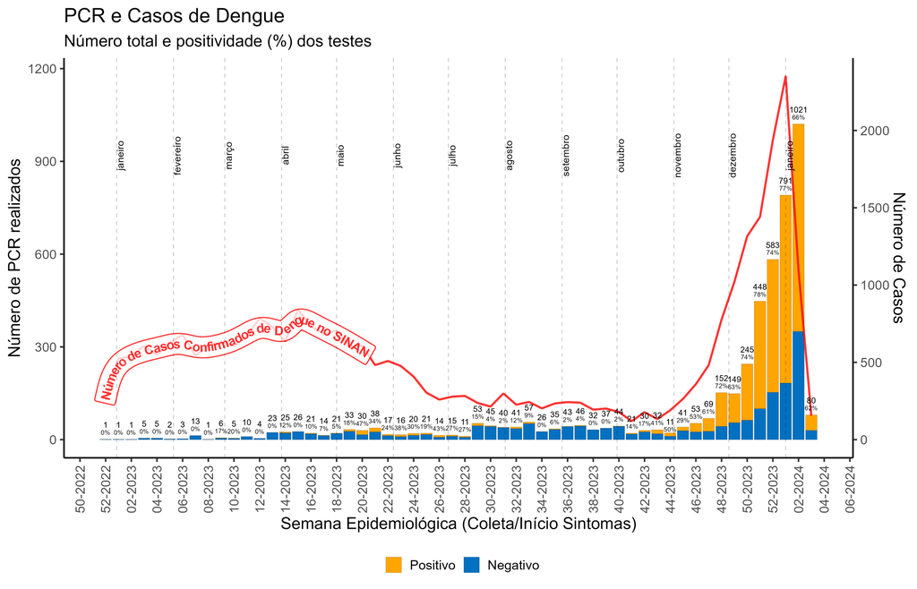

Número de testes PCR realizados (colunas) segundo resultado positivo (laranja) e negativo (azul) por Semana Epidemiológica de coleta da amostra. A linha vermelha indica a quantidade de casos por semana epidemiológica de início de sintomas. Atenção para as escalas diferentes das colunas (à esqueda) e dos casos (à direita).

O gráfico ilustra a correlação entre o número de casos confirmados de dengue registrados pelo SINAN e os resultados dos testes de PCR realizados ao longo do tempo, diferenciando entre positivos e negativos. Ao avaliar o gráfico, é crucial considerar que para melhore a visualização em um único gráfico foram escolhias diferentes escalas para as barras de teste (PCR) e para a linha vermelha (casos notificados), sendo que a linha representa quantidades 2x maiores. Isso é esperado, já que nem todos os casos são confirmados por PCR.

A recente diminuição nos casos confirmados de dengue observada no gráfico pode não refletir a situação real devido ao atraso na notificação e no encerramento das fichas do Sinan Online. Portanto, ainda se espera um aumento no número de casos notificados. A análise dos padrões de positividade dos testes rápidos e de sorologia também sugere que a manutenção de uma taxa de positividade acima de 30% pode ser um indicador antecipado de um possível aumento exacerbado nos casos de dengue. Mesmo para o caso de testes com menor especificidade como o teste rápido, positividades acima de 30% devem ser vitas como um alerta. Isso reforça a importância de monitorar a positividade dos testes como ferramenta preditiva para a vigilância epidemiológica da dengue.

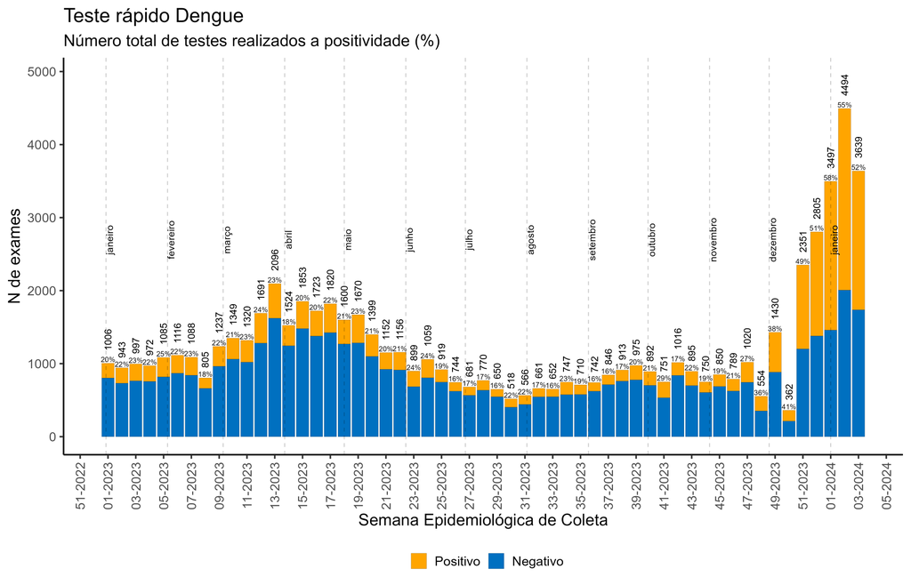

Número de testes rápido realizados (colunas) segundo resultado positivo (laranja) e negativo (azul) por Semana Epidemiológica de coleta da amostra. .

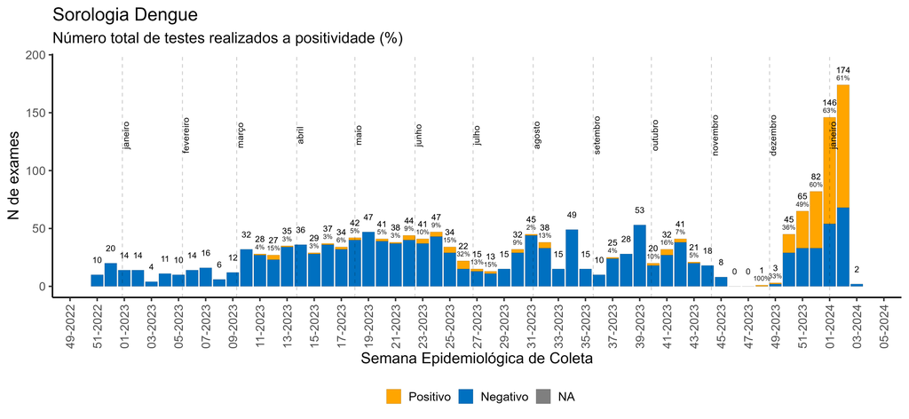

Número de testes sorológico realizados (colunas) segundo resultado positivo (laranja) e negativo (azul) por Semana Epidemiológica de coleta da amostra. .

## Perfil dos casos

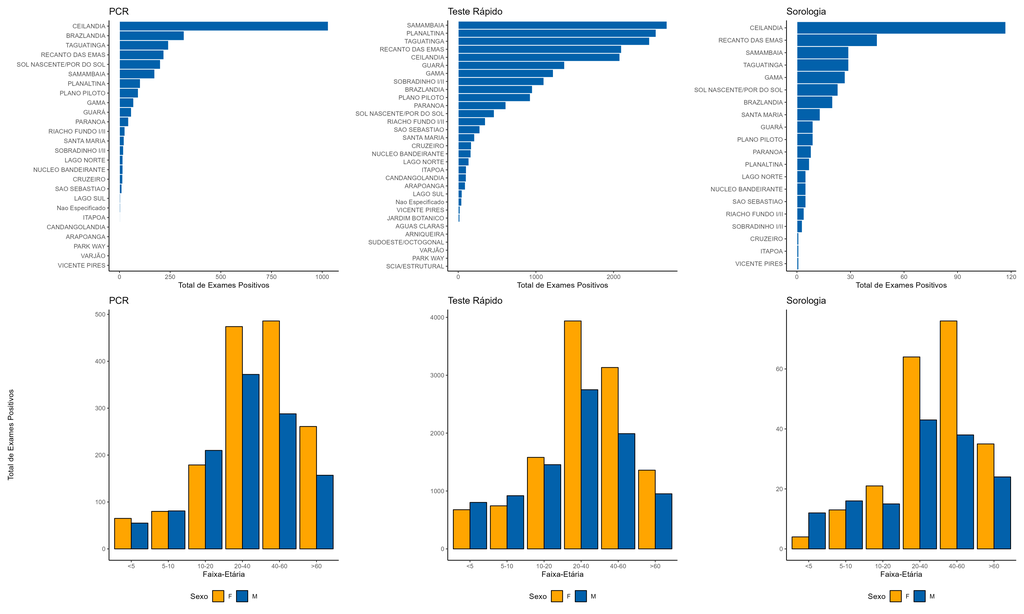

## Referências

*Guia de Vigilância em Saúde*. 2023. 6.ª ed. Brasil: Ministério da Saúde. https://www.gov.br/saude/pt-br/centrais-de-conteudo/publicacoes/svsa/vigilancia/guia-de-vigilancia-em-saude-volume-3-6a-edicao.

Wickham, Hadley, Mara Averick, Jennifer Bryan, Winston Chang, Lucy D’Agostino McGowan, Romain François, Garrett Grolemund, et al. 2019. "Welcome to the tidyverse". *Journal of Open Source Software* 4 (43): 1686. https://doi.org/10.21105/joss.01686.